# EasyVisa Project

## Boosting - Model Building and Hyperparameter Tuning

### AdaBoost Classifier

```python
# Lets define AdaBoost Classifier with random state = 1

abc = AdaBoostClassifier(random_state=1)
```

```python
# Lets fit AdaBoost Classifier on the train data

abc.fit(X_train,y_train)
```

```
AdaBoostClassifier(random_state=1)
```

### Checking model performance on training set

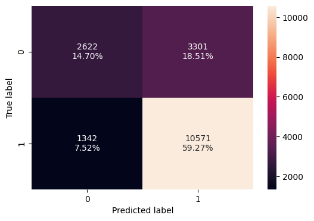

```python
# Lets create confusion matrix for train

confusion_matrix_sklearn(abc, X_train,y_train)
```

```python
# Lets check performance on train data

ab_classifier_model_train_perf = model_performance_classification_sklearn(abc, X_train, y_train)
ab_classifier_model_train_perf
```

|  | Accuracy | Recall | Precision | F1 |
| --- | --- | --- | --- | --- |
| 0 | 0.739684 | 0.88735 | 0.762039 | 0.819934 |

### Checking model performance on test set

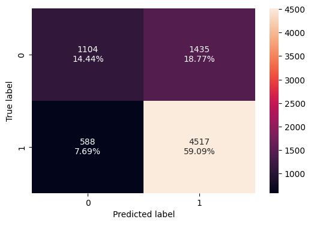

```python
# Lets create confusion matrix for test data

confusion_matrix_sklearn(abc,X_test,y_test)
```

```python
# Lets check performance on test data

ab_classifier_model_train_perf = model_performance_classification_sklearn(abc, X_test, y_test)
ab_classifier_model_train_perf
```

|  | Accuracy | Recall | Precision | F1 |
| --- | --- | --- | --- | --- |
| 0 | 0.735348 | 0.884819 | 0.758905 | 0.817039 |

- There is no overfitting on the training data using the AdaBoost classifier

### Hyperparameter Tuning - AdaBoost Classifier

```python
# Choose the type of classifier.
abc_tuned = AdaBoostClassifier(random_state=1)

# Grid of parameters to choose from

parameters = {

    # Let's try different max_depth for base_estimator
    "estimator": [
        DecisionTreeClassifier(max_depth=1, class_weight="balanced", random_state=1),
        DecisionTreeClassifier(max_depth=2, class_weight="balanced", random_state=1),
    ],
    "n_estimators": np.arange(80, 101, 10),
    "learning_rate": np.arange(0.1, 0.4, 0.1),
}

# Type of scoring used to compare parameter combinations
acc_scorer = metrics.make_scorer(metrics.f1_score)

# Run the grid search
grid_obj = GridSearchCV(abc_tuned, parameters, scoring=acc_scorer,cv=5)
grid_obj = grid_obj.fit(X_train, y_train)

# Set the clf to the best combination of parameters
abc_tuned = grid_obj.best_estimator_

# Fit the best algorithm to the data.
abc_tuned.fit(X_train, y_train)
```

```
AdaBoostClassifier(estimator=DecisionTreeClassifier(class_weight='balanced',
                                                    max_depth=1,
                                                    random_state=1),
                   learning_rate=np.float64(0.1), n_estimators=np.int64(80),
                   random_state=1)
```

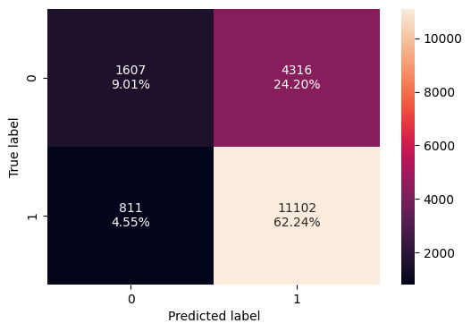

```python
# Lets create confusion matrix for train data on tuned estimator

confusion_matrix_sklearn(abc_tuned, X_train,y_train)
```

### Lets check the model performance on training set

```python
# Lets check performance for train data on tuned estimator

abc_tuned_model_train_perf=model_performance_classification_sklearn(abc_tuned, X_train,y_train)
print("Training performance \n",abc_tuned_model_train_perf)
```

```
Training performance
    Accuracy    Recall  Precision        F1
0  0.712548  0.931923   0.720067  0.812411
```

### Lets Check the model performance on test set

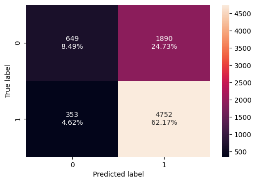

```python
# Lets create confusion matrix for test data on tuned estimator

confusion_matrix_sklearn(abc_tuned, X_test,y_test)
```

```python
# Lets check performance for test data on tuned estimator

abc_tuned_model_test_perf=model_performance_classification_sklearn(abc_tuned, X_test, y_test)
print("Testing performance \n",abc_tuned_model_test_perf)
```

```
Testing performance
    Accuracy    Recall  Precision        F1
0  0.706567  0.930852   0.715447  0.809058
```

- There is a reduction on the F1-score after hyperparameter tuning of the AdaBoost Model but no overfitting

### Gradient Boosting Classifier

```python
# Lets define GradientBoostingClassifier with random state = 1

gb_classifier = GradientBoostingClassifier(random_state=1)
```

```python
# Lets fit GradientBoostingClassifier on the train data

gb_classifier.fit(X_train,y_train)
```

```
GradientBoostingClassifier(random_state=1)
```

### Checking model performance on training set

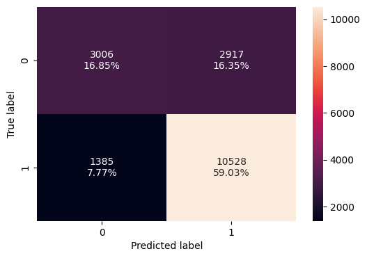

```python
# Lets create confusion matrix for train data

confusion_matrix_sklearn(gb_classifier, X_train,y_train)
```

```python
# Lets check the performance on train data

gb_classifier_model_train_perf = model_performance_classification_sklearn(gb_classifier, X_train, y_train)
gb_classifier_model_train_perf
```

|  | Accuracy | Recall | Precision | F1 |
| --- | --- | --- | --- | --- |
| 0 | 0.758802 | 0.88374 | 0.783042 | 0.830349 |

### Lets check the model performance on test set

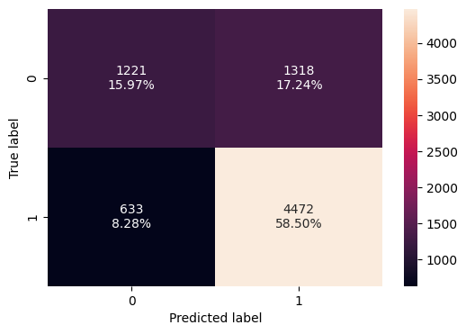

```python
# create confusion matrix for test data

confusion_matrix_sklearn(gb_classifier, X_test,y_test)
```

```python
# Lets check the performance on test data

gb_classifier_model_test_perf = model_performance_classification_sklearn(gb_classifier, X_test, y_test)
gb_classifier_model_test_perf
```

|  | Accuracy | Recall | Precision | F1 |
| --- | --- | --- | --- | --- |
| 0 | 0.744767 | 0.876004 | 0.772366 | 0.820927 |

- There is an improvement on the F1-score as compared to the previous model
- There is no overfitting on the training model
- Lets try Hyperparameter tuning and see if we will get an F1-score

### Hyperparameter Tuning - Gradient Boosting Classifier

```python
# Choose the type of classifier.
gbc_tuned = GradientBoostingClassifier(
    init=AdaBoostClassifier(random_state=1), random_state=1
)

# Grid of parameters to choose from
parameters = {
    "n_estimators": [200, 250],
    "subsample": [0.9, 1],
    "max_features": [0.8, 0.9],
    "learning_rate": np.arange(0.1, 0.21, 0.1),
}

# Type of scoring used to compare parameter combinations
acc_scorer = metrics.make_scorer(metrics.f1_score)

# Run the grid search
grid_obj = GridSearchCV(gbc_tuned, parameters, scoring=acc_scorer,cv=5)
grid_obj = grid_obj.fit(X_train, y_train)

# Set the clf to the best combination of parameters
gbc_tuned = grid_obj.best_estimator_

# Fit the best algorithm to the data.
gbc_tuned.fit(X_train, y_train)
```

```
GradientBoostingClassifier(init=AdaBoostClassifier(random_state=1),
                           learning_rate=np.float64(0.1), max_features=0.9,
                           n_estimators=200, random_state=1, subsample=0.9)
```

### Checking model performance on training set

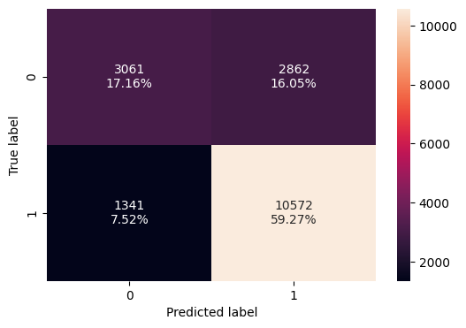

```python
# Lets create confusion matrix for train data on tuned estimator

confusion_matrix_sklearn(gbc_tuned, X_train,y_train)
```

```python
# Lets check performance for train data on tuned estimator

gbc_tuned_model_train_perf=model_performance_classification_sklearn(gbc_tuned, X_train,y_train)
print("Training performance \n",gbc_tuned_model_train_perf)
```

```
Training performance
    Accuracy    Recall  Precision        F1
0  0.764353  0.887434   0.786958  0.834182
```